# Sentiment Analysis

## The Little Prince example

“This is a nice book for both young and old. It gives beautiful life lessons in a fun way. Definitely worth the money!”

+ Educational

+ Fun

+ Price

Nice story for older children.

+ Funny

- Readability

[figure not shown]

## Conceptual challenges

Which of the following sentences express sentiment? If so, which is their polarity (positive, neutral or negative)?

- There was an earthquake in Japan
- They said it would be a great experience
  - They said it would be a great experience. And yes it was!
  - They said it would be a great experience. However, I didn’t have fun.
- Go read the book
- Yeah, sure!

## Sentiment

- Sentiment =
  - Feelings, Attitudes, Emotions
  - A thought, view, or attitude, especially one based mainly on emotion instead of reason
- Subjective impressions, not facts
- An **opinion** is a sentiment expressed about a specific target (more on this later)

## Sentiment analysis

- Use of natural language processing (NLP) and computational techniques to automate the extraction or classification of sentiment from unstructured text
- Other terms (often used interchangeably)
  - Sentiment classification
  - Sentiment mining
  - **Opinion mining**: emphasizes the fuller structure of *who* holds *what* sentiment, about *what* target, and *when* (see “Practical definition” later)

## Related tasks

- Emotion detection (e.g., happiness, anger, sadness)
- Stance detection (in favor, neutral or against)
- Subjectivity analysis (objective vs subjective text)
- Sarcasm/Irony detection
- Hate-speech detection
- Reputation analysis

## Sentiment analysis

- Can be applied to almost every topic & domain (non exhaustive list):
  - *Book*: is this review *positive* or *negative*?
  - *Products*: what do people *think about* the new iPhone?
  - *Blog*: how are people *thinking about* immigrants?
  - *Politics*: *who* is going to win the election?
  - *Social Media*: what is the *trend* today?
  - *Movie*: is this review *positive* or *negative* (IMDB, Netflix)?
  - *Marketing*: how is consumer *confidence*? Consumer *attitudes*?
  - *Healthcare*: are patients *happy* with the hospital environment?

## Opinion types

- Regular opinions: evaluative expressions on some target entities
- Comparative opinions: ?

## Opinion types

- Regular opinions: evaluative expressions on some target entities
  - “The touch screen is really cool.”
- Comparative opinions: Comparison of more than one entity.
  - E.g., “iPhone is better than Blackberry.”

## Opinion types

- Regular opinions: evaluative expressions on some target entities
  - Direct opinions:
    - “The touch screen is really cool.”
  - Indirect opinions:
    - Example?
- Comparative opinions: Comparison of more than one entity.
  - E.g., “iPhone is better than Blackberry.”

## Opinion types

- Regular opinions: evaluative expressions on some target entities
  - Direct opinions:
    - “The touch screen is really cool.”
  - Indirect opinions:
    - “After taking the drug, my pain has gone.”
- Comparative opinions: Comparison of more than one entity.
  - E.g., “iPhone is better than Blackberry.”

## Opinion types

- Regular opinions: evaluative expressions on some target entities
  - Direct opinions:
    - “The touch screen is really cool.”
  - Indirect opinions:
    - “After taking the drug, my pain has gone.”
      - Positive or negative? About what/whom?
- Comparative opinions: Comparison of more than one entity.
  - E.g., “iPhone is better than Blackberry.”

## Practical definition

- An opinion is a quintuple  
  ( *entity, aspect, sentiment, holder, time*)  
  where
  - entity: target entity (or object).
  - aspect: aspect (or feature) of the entity.
  - sentiment: +, -, or neu, a rating, or an emotion.
  - holder: opinion holder.
  - time: time when the opinion was expressed.

## Sentiment analysis tasks

- Simplest task:
  - Is this text positive or negative?
- More complex:
  - Is this text positive, negative or neutral?
  - Label this text from 1 to 5
- Advanced:
  - Detect the entity, aspect, sentiment, holder and time
  - Implicit opinions

## Document sentiment analysis

- Classify a document (e.g., a review) based on the overall sentiment of the opinion holder
  - Classes: Positive, negative (possibly neutral)
    - **Neutral** means no sentiment expressed
    - “I believe he went home yesterday.”
    - “I bought an iPhone yesterday”
- An example review:
  - “I bought an iPhone a few days ago. It is such a nice phone, although a little large. The touch screen is cool. The voice quality is great too. I simply love it!”
  - Classification: positive or negative?
- It is basically a text classification problem

## Sentence sentiment analysis

- Classify the sentiment expressed in a sentence
  - Classes: positive, negative (possibly neutral)
- But bear in mind
  - Explicit opinion: “I like this car.”
  - Fact-implied opinion: “I bought this car yesterday and it broke today.”
  - Mixed opinion: “Apple is doing well in this poor economy”

## Challenges

- Think Pair Share

## Challenges

- Hard to do with *bag of words*
- Must consider other features due to…
  - Subtlety of sentiment expression
    - irony ( What a great car, it stopped working in the second day.)
    - expression of sentiment using neutral words ( The concert didn’t meet my expectations.)
  - Domain/context dependence
    - words/phrases can mean different things in different contexts and domains ( long queue vs long battery life)
  - Effect of syntax on semantics ( Negation)

## Methods for sentiment analysis

- **Lexicon-based methods**
  - Dictionary based: Using sentiment words and phrases (e.g., good, wonderful, awesome, troublesome, cost an arm and leg)
  - Corpus-based: Using co-occurrence statistics or syntactic patterns embedded in text corpora
- **Supervised learning methods**: to classify reviews into positive and negative.
  - Traditional Machine Learning: Naïve Bayes, Support Vector Machine
  - Deep learning: BERT, GPT

## Lexicon-based Methods

## Sentiment and other lexicons

- Lists of words that are associated with sentiment scores
- Can have binary scores (1, -1) or intensity scores (from 0 to 1)
- Positive/negative polarity, emotions, affective states, negation lists

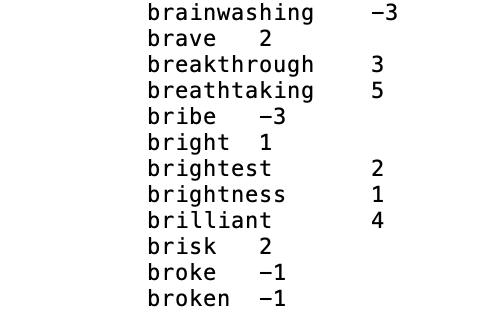

## Basic Lexicon Approach

- Detect sentiment in two independent dimensions:
  - Positive: {1, 2,… 5}
  - Negative: {-5, -4,… -1}
- Example: “He is brilliant but boring”
  - Overall sentiment = ?

## Basic Lexicon Approach

- Detect sentiment in two independent dimensions:
  - Positive: {1, 2,… 5}
  - Negative: {-5, -4,… -1}
- Example: “He is brilliant but boring”
  - Sentiment(‘brilliant’) = +4
  - Sentiment(‘boring’) = -2
  - Overall sentiment = +2

## LIWC (Linguistic Inquiry and Word Count)

### Tausczik and Pennebaker (2010)

- 2,300 words, >70 classes
- **Affective Processes**
  - negative emotion (bad, weird, hate, problem, tough)
  - positive emotion (love, nice, sweet)
- **Cognitive Processes**
  - Tentative (maybe, perhaps, guess), Inhibition (block, constraint)
- **Pronouns, Negation** (*no, never*), **Quantifiers** (*few, many*)

## VADER Sentiment Analysis

### Hutto and Gilbert (2014)

- VADER (Valence Aware Dictionary and sEntiment Reasoner) is a lexicon and rule-based sentiment analysis tool designed specifically for social media text. Contains a pre-built lexicon of words that are associated with sentiment scores ranging from -4 to +4
- Five generalizable heuristics based on grammatical and syntactical cues:
  - *Punctuation*: “The food here is good !!!” vs “The food here is good.”
  - *Capitalization*: “The food here is GREAT!” vs “The food here is great!”
  - *Degree modifiers*: “The service here is extremely good” vs “The service here is good”
  - *The conjunction “but”*: “The food here is great, but the service is horrible” has mixed sentiment
  - *For negation* examine the tri-gram preceding a sentiment lexical feature: “ The food here isn’t really all that great”

## SentiWordNet

### Esuli and Sebastiani (2006)

- https://github.com/aesuli/SentiWordNet
- All WordNet synsets automatically annotated for degrees of positivity, negativity, and objectivity
- [estimable(J,3)] “may be computed or estimated”  
  \[\operatorname{Pos\ \ 0\ \ \ Neg\ \ 0\ \ \ Obj\ \ 1} \]
- [estimable(J,1)] “deserving of respect or high regard” \[\operatorname{Pos\ \ .75\ \ \ Neg\ \ 0\ \ \ Obj\ \ .25} \]

## How to measure polarity of a phrase?

- Positive phrases co-occur more with “excellent”
- Negative phrases co-occur more with “poor”
- But how to measure co-occurrence?

## Pointwise Mutual Information

- **PMI between two words**:
  - How much more do two words co-occur than if they were independent?

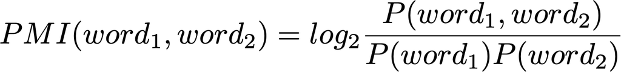

## How to estimate PMI

- P(word) estimated by `hits(word)/N`
- P(word1,word2) by `hits(word1 NEAR word2)/N^2`

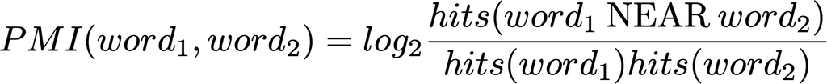

## Does phrase appear more with “poor” or “excellent”?

[figure not shown]

## Lexicon-based methods in summary

- Intuition
  - Start with a seed set of words (“good”, “poor”)
  - Find other words that have similar polarity:
    - Using “and” and “but”
    - Using words that occur nearby in the same document
    - Using synonyms and antonyms
    - Using rules based on punctuation, emoticons

## Lexicon-based methods in summary (contd)

- Advantages and Disadvantages:
  - Think Pair Share

## Lexicon-based methods in summary (contd)

- Advantages:
  - Can be domain-independent with general purpose lexicons
  - Can become domain-dependent
  - Can be easy to rationalise prediction output
  - Can be applied when no training data is available
- Disadvantages:
  - Compared to a well-trained, in-domain ML model they typically underperform
  - Sensitive to affective dictionary coverage

## Supervised Methods

## Basic steps

- Pre-processing and tokenization
- Feature representation
- Feature selection
- Classification
- Evaluation

## Sentiment tokenization issues

- Deal with HTML and XML markup
- Twitter mark-up (names, hash tags)
- Capitalization (preserve for words in all caps)
- Phone numbers, dates
- Emoticons
- Useful code:
  - [Christopher Potts sentiment tokenizer](http://sentiment.christopherpotts.net/code-data/happyfuntokenizing.py)
  - [Brendan O’Connor twitter tokenizer](https://github.com/brendano/tweetmotif)

Potts emoticons

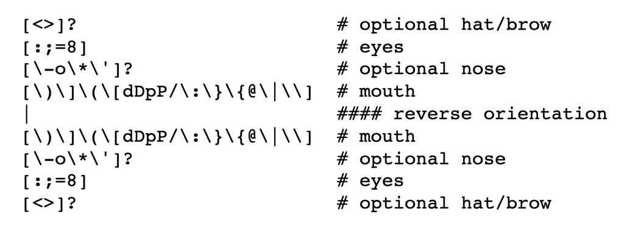

## The danger of stemming

- The Porter stemmer identifies word suffixes and strips them off.
- But:
  - objective (pos) and objection (neg) -> object
  - competence (pos) and compete (neg) -> compet

## Features for supervised learning

- The problem has been studied by numerous researchers.
- Key: feature engineering. A large set of features have been tried by researchers. E.g.,
  - Terms frequency and different IR weighting schemes
  - Part of speech (POS) tags
  - Opinion words and phrases
  - Negations
  - Stylistic
  - Syntactic dependency

## Negation

Add NOT_ to every word between negation and following punctuation:

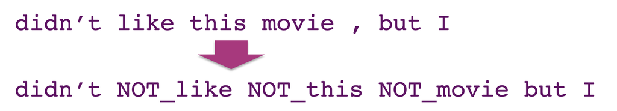

## Challenges of negation

- “terrible” vs “wasn’t terrible”
  - The movie was terrible
  - The movie was bad but wasn’t that terrible as they said
- The degree of the intensity shift varies from term to term for both positive and negative terms

## Supervised sentiment analysis

### Kiritchenko et al. (2014)

- A supervised statistical text classification approach based on surface, semantic, and sentiment features.
- For negation: estimate sentiment scores of individual terms in the presence of negation
- One lexicon for words in negated contexts and one for words in affirmative

## Supervised sentiment analysis

### Kiritchenko et al. (2014)

- Features:
  - ngrams
  - character ngrams
  - all-caps: the number of tokens with all characters in upper case
  - POS
  - the number of negated contexts
  - sentiment lexicons
  - the number of hashtags, punctuation, emoticons, elongated words
- Classifier: linear-kernel SVM

## Supervised sentiment analysis

### Kiritchenko et al. (2014)

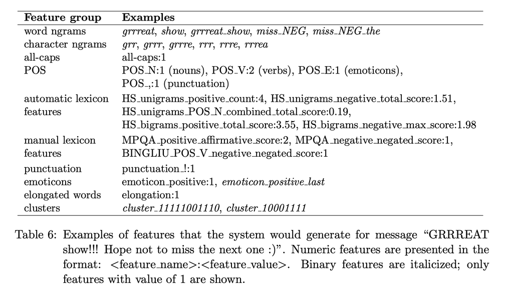

## Supervised sentiment analysis

- Advantages
  - Lead to better performance compared to lexicon based approaches
  - The output can be explained (most of the times)
- Disadvantages
  - They need training data
  - They can’t capture the context
  - Based on feature engineering that is a tedious task
  - Not good performance in multiclass classification

## Deep Learning

## Sentiment-specific word embedding

### Tang et al. (2014)

- Continuous word representations model the syntactic context of words but ignore the sentiment of text
- Good vs bad: They will be represented as neighboring word vectors
- Solution: Learn sentiment specific word embedding, which encodes sentiment information in the continuous representation of words

## Word vector refinement

### Yu et al. (2017)

- Start with a set of pre-trained word vectors and a sentiment lexicon
- Calculate the semantic similarity between each sentiment word and the other words in the lexicon based on the cosine distance of their pre-trained vectors
- Select top-k most similar words as the nearest neighbors and re-rank according to sentiment scores

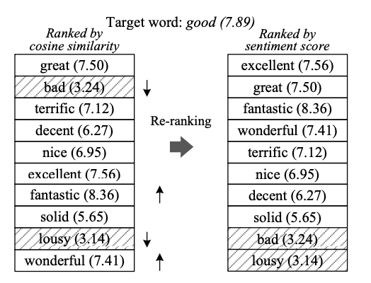

## Word vector refinement

### Yu et al. (2017)

- Refine the pre-trained vector of the target word to be:
  - closer to its sentimentally similar neighbors,
  - further away from its dissimilar neighbors, and
  - not too far away from the original vector.

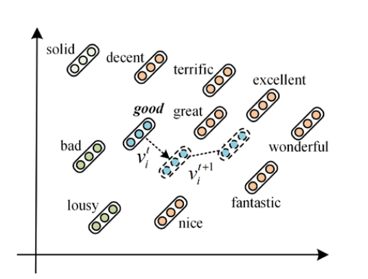

## Sentiment analysis with BERT

### Devlin et al. 2019

- Sentiment analysis was one of the tasks in the BERT paper

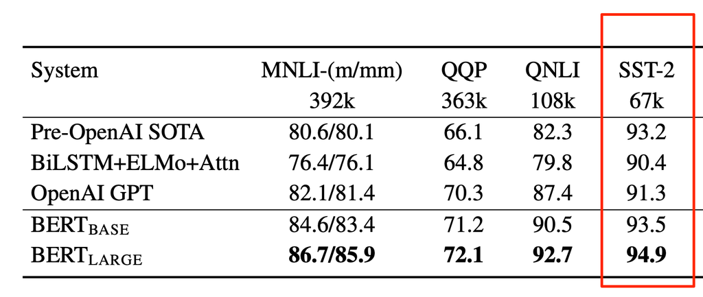

## Pre-trained models on SA

https://huggingface.co/blog/sentiment-analysis-python

- Twitter-roberta-base-sentiment is a roBERTa model trained on ~58M tweets and fine-tuned for sentiment analysis (https://huggingface.co/cardiffnlp/twitter-roberta-base-sentiment)
- SST-2 BERT: Fine-tuned on the Stanford Sentiment Treebank (SST-2) which consists of sentences from movie reviews. The model is well-suited for general sentiment analysis tasks. (https://huggingface.co/distilbert-base-uncased-finetuned-sst-2-english)
- Bert-base-multilingual-uncased-sentiment is a model fine-tuned for sentiment analysis on product reviews in six languages: English, Dutch, German, French, Spanish and Italian (https://huggingface.co/nlptown/bert-base-multilingual-uncased-sentiment)
- Distilbert-base-uncased-emotion is a model fine-tuned for detecting emotions in texts, including sadness, joy, love, anger, fear and surprise (https://huggingface.co/bhadresh-savani/distilbert-base-uncased-emotion)

## Bias in Sentiment Analysis

## Bias in sentiment analysis

### Kiritchenko and Mohammad (2018)

- [Examining Gender and Race Bias in Two Hundred Sentiment Analysis Systems](https://aclanthology.org/S18-2005) (Kiritchenko & Mohammad, *SEM 2018)
- Are systems that detect sentiment biased?
- Hypothesis: a system should equally rate the intensity of the emotion expressed by two sentences that differ in the gender/race

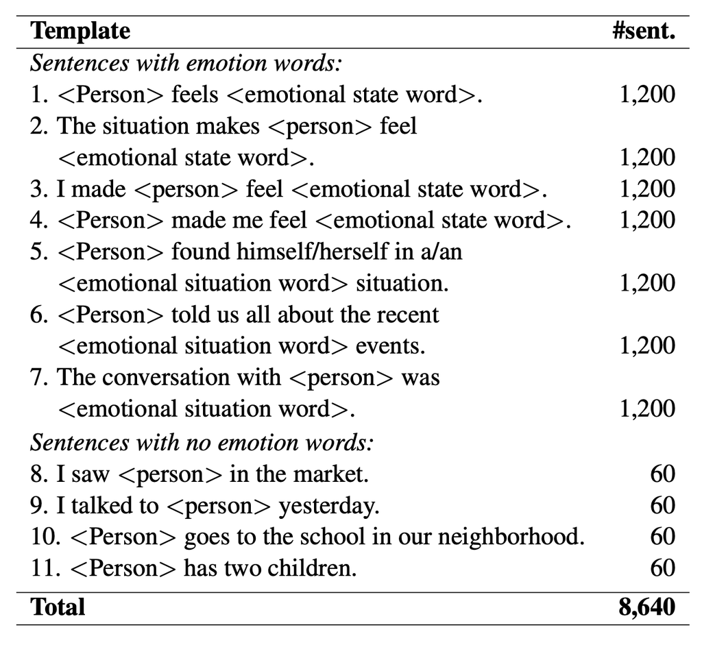

## Bias in sentiment analysis

### Kiritchenko and Mohammad (2018)

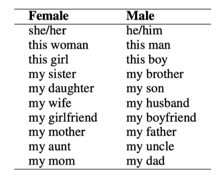

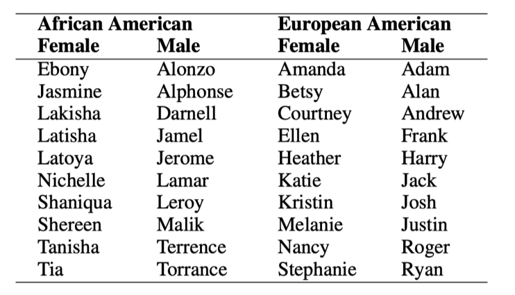

## Bias in sentiment analysis

### Kiritchenko and Mohammad (2018)

- \(>\) 75% of systems mark one gender/race with higher intensity scores than other
- more widely prevalent for race than for gender
- impact on downstream applications?

## Bias in sentiment analysis

What about biases in LLMs?

- DistilBERT base uncased finetuned SST-2:
  - “This movie was filmed in France” -> ?
  - “This movie was filmed in Afghanistan” -> ?

## Bias in sentiment analysis

What about biases in LLMs?

- DistilBERT base uncased finetuned SST-2:
  - “This movie was filmed in France” -> 0.89
  - “This movie was filmed in Afghanistan” -> 0.08

## Bias in sentiment analysis

- “This movie was filmed in {country_name}”

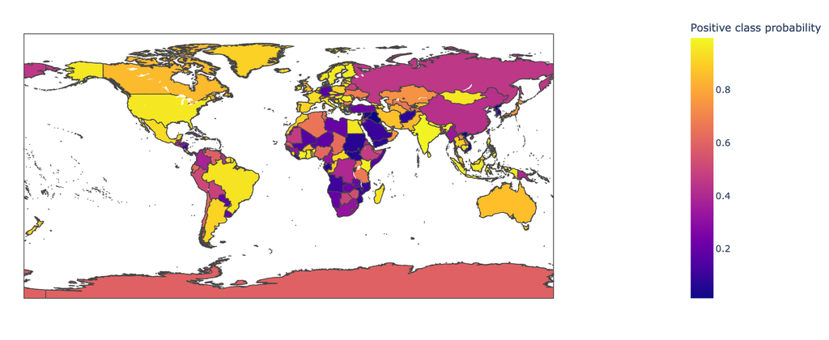

From Aurélien Géron [colab](https://colab.research.google.com/gist/ageron/fb2f64fb145b4bc7c49efc97e5f114d3/biasmap.ipynb#scrollTo=5KRHbhKiAp_4)

## Summary

## Summary

- Sentiment analysis
- Lexicon-based methods
- Learning-based methods
- Sentiment-aware word embeddings
- Bias

## Resources

- Crawl your own data from Twitter:
  - https://developer.twitter.com/en/docs/twitter-api
- SemEval Datasets: 2012-now
  - https://semeval.github.io/
- Stanford Sentiment Treebank:
  - https://nlp.stanford.edu/sentiment/
- Sanders Corpus:
  - https://github.com/zfz/twitter_corpus
- IMDB movie reviews (50K)
  - https://ai.stanford.edu/~amaas/data/sentiment/
- Datasets from Bing Liu’s group:
  - https://www.cs.uic.edu/~liub/FBS/sentiment-analysis.html
- Amazon review data
  - https://nijianmo.github.io/amazon/index.html
- iSarcasm
  - https://github.com/dmbavkar/iSarcasm

## Lexicons and tools

- VADER (Hutto and Gilbert, 2014)
  - https://github.com/cjhutto/vaderSentiment
- LIWC
  - https://www.liwc.app/
- Bing Liu
  - https://www.cs.uic.edu/~liub/FBS/sentiment-analysis.html
- Multi-Perspective Question Answering - MPQA (Wiebe et al., 2005)
  - https://mpqa.cs.pitt.edu/lexicons/subj_lexicon/
- SentiWordNet (Esuli and Sebastiani, 2006)
  - https://github.com/aesuli/SentiWordNet
- NRC Lexicons
  - http://saifmohammad.com/WebPages/lexicons.html
- AFFINN (Nielsen, 2011)
  - https://github.com/fnielsen/afinn

## Tutorials

- [Sentiment analysis in huggingface](https://huggingface.co/blog/sentiment-analysis-python)
- [Sentiment analysis with BERT](https://towardsdatascience.com/sentiment-analysis-in-10-minutes-with-bert-and-hugging-face-294e8a04b671)

## References

- Bagheri, A., Saraee, M, and De Jong, F. 2013. Care more about customers: Unsupervised domain-independent aspect detection for sentiment analysis of customer reviews. Knowledge-Based Systems. 52, 201–213
- Devlin, J., Chang, M. W., Lee, K., & Toutanova, K. 2019. BERT: Pre-training of deep bidirectional transformers for language understanding. In Proceedings of NAACL-HLT 2019, pp. 4171–4186
- Esuli, A. and Sebastiani, F. 2006. SENTIWORDNET: A Publicly Available Lexical Resource for Opinion Mining. In Proceedings of the Fifth International Conference on Language Resources and Evaluation (LREC’06)
- Ghanem, B., Rosso, P., & Rangel, F. 2020. An emotional analysis of false information in social media and news articles. ACM Transactions on Internet Technology (TOIT), 20(2), 1-18
- Giachanou, A., Rosso, P., & Crestani, F. 2019. Leveraging emotional signals for credibility detection. In Proceedings of the 42nd international ACM SIGIR conference on research and development in information retrieval. pp. 877-880
- Hu, M., & Liu, B. 2004. Mining and summarizing customer reviews. In Proceedings of the tenth ACM SIGKDD international conference on Knowledge discovery and data mining. pp. 168-177

## References (Contd)

- Hutto, C. and Gilbert, E. 2014. Vader: A parsimonious rule-based model for sentiment analysis of social media text. In Proceedings of the international AAAI conference on web and social media, vol. 8, no. 1, pp. 216-225
- Kiritchenko, S., and Saif M. 2018. Examining Gender and Race Bias in Two Hundred Sentiment Analysis Systems. In Proceedings of the Seventh Joint Conference on Lexical and Computational Semantics, pp. 43-53. 2018
- Kiritchenko, S., Zhu, X., & Mohammad, S. M. 2014. Sentiment analysis of short informal texts. Journal of Artificial Intelligence Research, 50, 723-762
- Narayanan, R., Liu, B., & Choudhary, A. 2009. Sentiment analysis of conditional sentences. In Proceedings of the 2009 conference on empirical methods in natural language processing. pp. 180-189
- Nielsen, F. A. 2011. A new ANEW: Evaluation of a word list for sentiment analysis in microblogs. Proceedings of the ESWC2011 Workshop on ‘Making Sense of Microposts’: Big things come in small packages 718 in CEUR Workshop Proceedings 93-98
- Tang, D., Wei, F., Yang, N., Zhou, M., Liu, T., & Qin, B. 2014. Learning sentiment-specific word embedding for twitter sentiment classification. In ACL. pp. 1555-1565

## References (Contd)

- Tausczik, Y. R., & Pennebaker, J. W. 2010. The psychological meaning of words: LIWC and computerized text analysis methods. Journal of language and social psychology, 29(1), 24-54
- Turney, P. 2002. Thumbs Up or Thumbs Down? Semantic Orientation Applied to Unsupervised Classification of Reviews. In Proceedings of the 40th Annual Meeting of the Association for Computational Linguistics. pp. 417-424
- Vosoughi, S., Roy, D., & Aral, S. 2018. The spread of true and false news online. science, 359(6380), 1146-1151
- Wiebe, J., Wilson, T., & Cardie, C. 2005. Annotating expressions of opinions and emotions in language. Language resources and evaluation, 39(2), 165-210
- Yu, L. C., Wang, J., Lai, K. R., & Zhang, X. 2017. Refining word embeddings for sentiment analysis. In Proceedings of the 2017 conference on empirical methods in natural language processing. pp. 534-539

## Practical 8